# RC1_Exercise

Haohong Shang

2023-05-15

### Auto data

- Load the Auto dataset from *Auto.csv* using the read.csv() function. Show the top 5 rows.
- Make a boxplot of *cylinders* versus *mpg* and a histogram of *mpg*. Display them in the same row.
- Set the seed to be 100. Generate a vector *x_0* from standard normal distribution. The length should be equal to the row number of Auto.
- Make 4 scatterplots within a 2*2 block. Points within each plot should be in gray color. Use a for-loop with parameter **i** from 4 to 1. Within each plot (5-i), **x** should be the vector “weight” of *Auto.csv*; and **y** should be equal to i*x_0 + i^2. Append a blue dash line with line width=2. Make the title of each plot (5-i) to be “Figure (5-i)”. Your output should be similar to the picture below. You may need to search for the usage the function **paste()** and **abline()**.
- Type the formula “y = i*x_0 + i^2” using LaTeX in display mode(i.e. at the center).

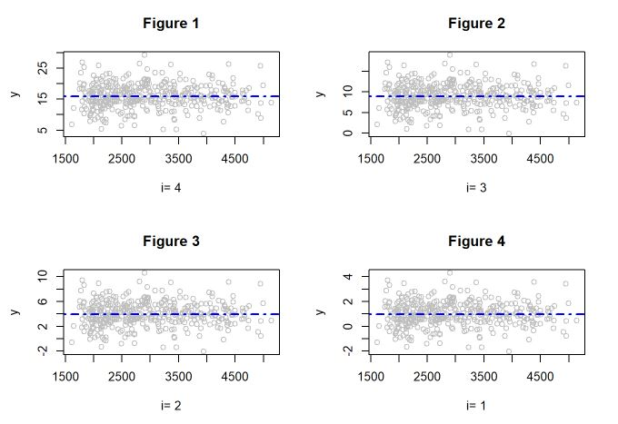